# Practicals - basic peak-calling statistics

Jacques van Helden

2017-02-01

# Introduction

The goal of this tutorial is to explore ChIP-seq data and to evaluate various statistics and graphical modes in order to detect peaks, i.e. regions with a significantly higher number of reads than what would be expected based on some background model.

We will use a dataset from the bacteria *Escherichia coli K12*. Since bacteria have a relatively small genome compared to metazoans, the ChIP-seq dataset achieves a very high coverage, which gives us particularly interesting conditions to assess the validity of our prior assumptions.

# Tasks

1. Load the ChIP-seq coverage profile and the genomic input.
2. Compute and represent graphically the distributions of counts per bin.
3. Compute and draw the Lorenz curves for the ChIP-seq data and for the genomic input.
4. Compute various scores that might be used to compare the counts per bin between ChIP-ped and input datasets.
5. Based on the Poisson distribution, compute a value per bin, as well as an adjusted p-value (corrected for multiple testing).
6. Draw a volcano plot with the log2-fold-change as measure of the effect size (abscissa) and the $-log_{10}(p_{adj})$ on the ordinate.
7. Select the significant bins.
8. Load the results in IGV and compare the results with the peaks returned by a real peak-caller.

# Data loading

We will first load the datasets.

We will load bedgraph-formatted files indicating the counts of reads per 200bp window along *E.coli* genome.

```r
## Define the base URL of the course and store it in a variable
url.course <- "http://jvanheld.github.io/stats_avec_RStudio_EBA/"

## Define the fill path of the data directory, by concatenating the course URL and all the successive folders
url.data <- file.path(url.course, "practicals", "02_peak-calling", "data")
```

```r
## Define URL of the ChIP file
chip.bedg.file <- file.path(url.data, "FNR_200bp.bedg")
print(chip.bedg.file)
```

```
## [1] "http://jvanheld.github.io/stats_avec_RStudio_EBA//practicals/02_peak-calling/data/FNR_200bp.bedg"
```

```r
## Load the file content in an R data.frame
chip.bedg <- read.table(chip.bedg.file)

## Set column names
names(chip.bedg) <- c("chrom", "start", "end","counts")


## Check the dimensions of the bedgraph for the ChIP-seq
dim(chip.bedg)
```

```
## [1] 23199     4
```

```r
summary(chip.bedg)
```

```
##                           chrom           start              end
##  gi|49175990|ref|NC_000913.2|:23199   Min.   :      0   Min.   :    200
##                                       1st Qu.:1159900   1st Qu.:1160100
##                                       Median :2319800   Median :2320000
##                                       Mean   :2319800   Mean   :2320000
##                                       3rd Qu.:3479700   3rd Qu.:3479900
##                                       Max.   :4639600   Max.   :4639675
##      counts
##  Min.   :    0
##  1st Qu.:   82
##  Median :  101
##  Mean   :  113
##  3rd Qu.:  125
##  Max.   :12411
```

We loaded a tab-delimited file with the counts of reads per window in the FNR ChIP-seq sample. The table contains 23199 rows, each row corresponding to a genomic window.

```r
## Define URL of the input file
input.bedg.file <- file.path(url.data, "input_200bp.bedg")

## Load the file content in an R data.frame
input.bedg <- read.table(input.bedg.file)

## Set column names
names(input.bedg) <- c("chrom", "start", "end","counts")
```

# Results

## Histograms of counts per window

We will first compare the distribution of counts per windows in ChIP-seq and input, respectively.

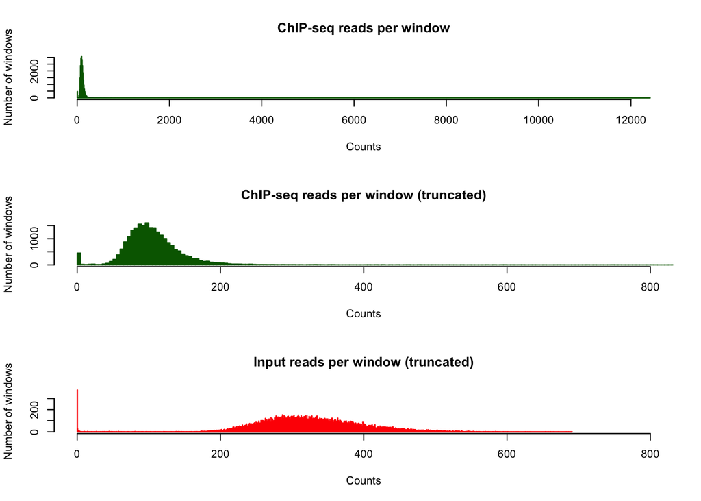

```r
par(mfrow=c(3,1))

## Histogram of counts per window for the ChIP-seq sample
hist(chip.bedg$counts,
     main="ChIP-seq reads per window",
     ylab="Number of windows",
     xlab="Counts",
     col="darkgreen", border = "darkgreen",
     breaks= 1000)


hist(chip.bedg$counts,
     main="ChIP-seq reads per window (truncated)",
     ylab="Number of windows",
     xlab="Counts", xlim=c(0,800),
     col="darkgreen", border = "darkgreen",
     breaks= 2000)

hist(input.bedg$counts,
     main="Input reads per window (truncated)",
     ylab="Number of windows",
     xlab="Counts", xlim=c(0,800),
     col="red", border = "red",
     breaks= 2000)
```

```r
par(mfrow=c(1,1))
```

## Compute log2(counts)

```r
count.stats <- data.frame(chip.counts= chip.bedg$counts,
                          input.counts = input.bedg$counts)


epsilon <- 1/16
count.stats$chip.epsilon <- count.stats$chip.counts
count.stats$chip.epsilon[count.stats$chip.counts==0] <- epsilon
count.stats$input.epsilon <- count.stats$input.counts
count.stats$input.epsilon[count.stats$input.counts==0] <- epsilon

count.stats$chip.log2.counts <- log2(count.stats$chip.epsilon)
count.stats$input.log2.counts <- log2(count.stats$input.epsilon)

summary(count.stats)
```

```
##   chip.counts     input.counts    chip.epsilon       input.epsilon
##  Min.   :    0   Min.   :  0.0   Min.   :    0.062   Min.   :  0.0625
##  1st Qu.:   82   1st Qu.:277.0   1st Qu.:   82.000   1st Qu.:277.0000
##  Median :  101   Median :320.0   Median :  101.000   Median :320.0000
##  Mean   :  113   Mean   :322.4   Mean   :  113.030   Mean   :322.4459
##  3rd Qu.:  125   3rd Qu.:372.0   3rd Qu.:  125.000   3rd Qu.:372.0000
##  Max.   :12411   Max.   :691.0   Max.   :12411.000   Max.   :691.0000
##  chip.log2.counts input.log2.counts
##  Min.   :-4.000   Min.   :-4.000
##  1st Qu.: 6.358   1st Qu.: 8.114
##  Median : 6.658   Median : 8.322
##  Mean   : 6.498   Mean   : 8.099
##  3rd Qu.: 6.966   3rd Qu.: 8.539
##  Max.   :13.599   Max.   : 9.433
```

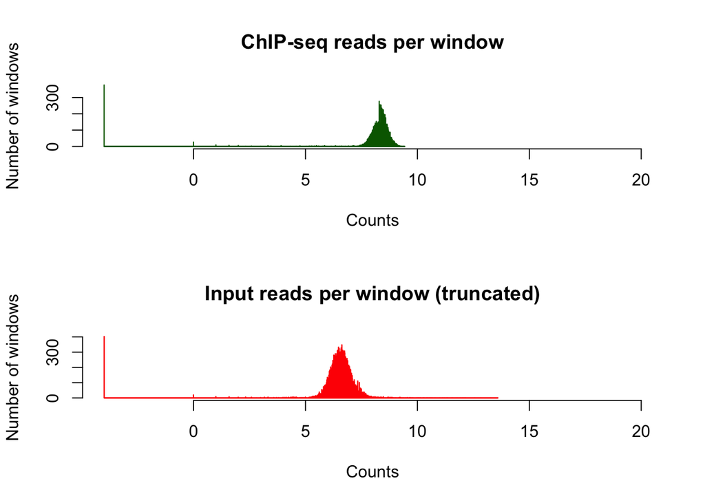

```r
par(mfrow=c(2,1))

## Histogram of counts per window for the ChIP-seq sample
hist(count.stats$input.log2.counts,
     main="ChIP-seq reads per window",
     ylab="Number of windows",
     xlab="Counts", xlim=c(-4, 20),
     col="darkgreen", border = "darkgreen",
     breaks= 2000)

hist(count.stats$chip.log2.counts,
     main="Input reads per window (truncated)",
     ylab="Number of windows",
     xlab="Counts",  xlim=c(-4, 20),
     col="red", border = "red",
     breaks= 2000)
```

```r
par(mfrow=c(1,1))
```

## Compute the mean position per window

```r
## Compute the middle position for each window
chip.bedg$midpos <- (chip.bedg$start + chip.bedg$end)/2

## Check the result
head(chip.bedg)
```

```
##                          chrom start  end counts midpos
## 1 gi|49175990|ref|NC_000913.2|     0  200   1594    100
## 2 gi|49175990|ref|NC_000913.2|   200  400    834    300
## 3 gi|49175990|ref|NC_000913.2|   400  600    222    500
## 4 gi|49175990|ref|NC_000913.2|   600  800    172    700
## 5 gi|49175990|ref|NC_000913.2|   800 1000    123    900
## 6 gi|49175990|ref|NC_000913.2|  1000 1200    116   1100
```

## Plot the coverage profiles of the FNR ChIP-seq and input samples

We will plot on top of each other the coverage profiles of the ChIP-seq (FNR) and input samples.

Figure 1 shows the coverage profiles of the ChIP-seq (top panel, darkgreen) and input (bottom panel, red) samples.

Note the huge difference of scale: the input has a maximum of 691 counts per bin, whereas the highest ChIP-seq bin contains 12411 counts.

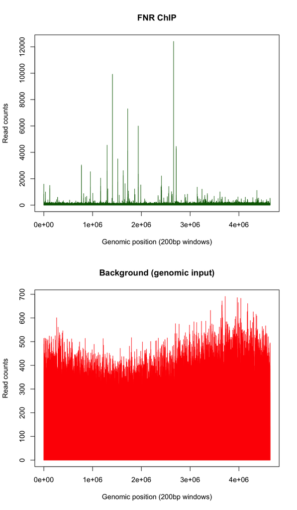

**Figure 1.** Coverage profiles of the ChIP-seq (dark green) and input (red) samples.

```r
par(mfrow=c(2,1))

plot(x = chip.bedg$midpos,
     y = chip.bedg$counts,
     col="darkgreen",
     main="FNR ChIP",
     xlab="Genomic position (200bp windows)",
     ylab="Read counts",
     type="h")

## Compute middle positions per window
input.bedg$midpos <- (input.bedg$start + input.bedg$end)/2

plot(input.bedg[, c("midpos", "counts")],
     col="red",
     main="Background (genomic input)",
     xlab="Genomic position (200bp windows)",
     ylab= "Read counts",
     type="h")
```

```r
par(mfrow=c(1,1))
```

## Normalization

We would like to draw a differential profile, by substracting the input from the CHIP-seq. However, this must be done on the normalized counts, in order to compensate the differences of library sizes.

### Library sizes

```r
## Compute the library sizes and their ratio
input.libsize <- sum(input.bedg$counts)
chip.libsize <- sum(chip.bedg$counts)
libsize.ratio <- chip.libsize / input.libsize
```

The library sizes are very different between the ChIP-seq sample (2622163 reads) and the input (7480400). We thus need to normalize the libraries in order to ensure a consistent scaling.

A naive way to normalize would be to multiply the input library by a scaling factor $s$, in order to bring it to the same size as the input.

$$s = N_{\text{chip}} / N_{\text{input}}$$

### Median-based scaling

The median is a robust estimate of the central tendency, since its value only depends on the centralmost part of hte distribution. We can use it as scaling factor to compensate the differences in library sizes.

```r
input.median <- median(count.stats$input.counts)
chip.median <- median(count.stats$chip.counts)
median.ratio <- chip.median / input.median

count.stats$input.median.norm <- count.stats$input.counts * print(median.ratio)
```

```
## [1] 0.315625
```

### Compute cumulative distribution of read counts per window

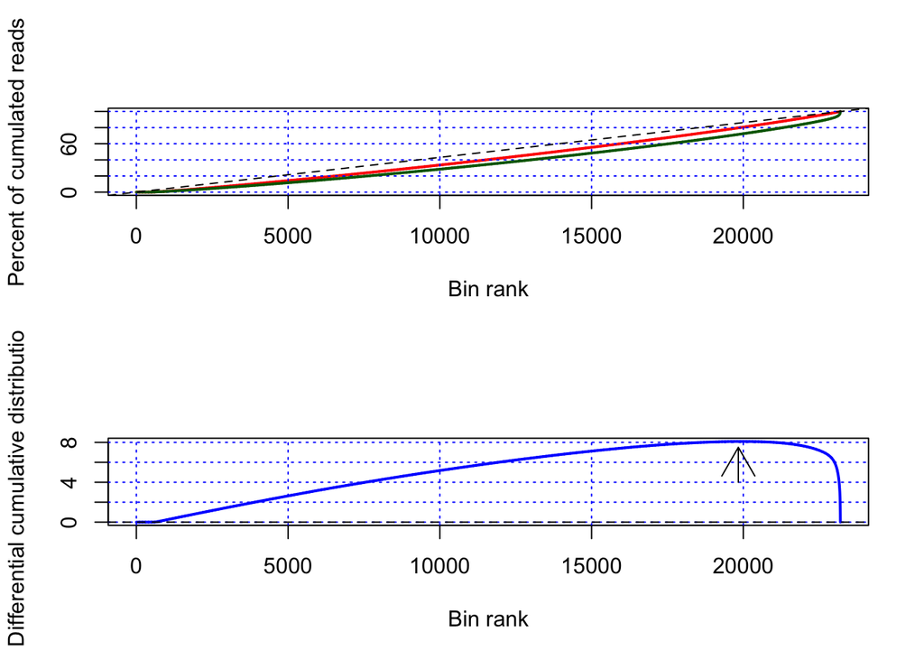

```r
## Beware, we rank the bins by increasing counts to get the empty bins first and the densest bins last
count.stats$chip.rank <- rank(count.stats$chip.counts)
count.stats$input.rank <- rank(count.stats$input.counts)

## Compare the ranks
#plot(count.stats$chip.rank, count.stats$input.rank)

## Compute cumulative counts per rank
chip.cumsum <- cumsum (sort(count.stats$chip.counts))
input.cumsum <- cumsum (sort(count.stats$input.counts))
chip.cumpercent <- chip.cumsum / max(chip.cumsum)*100
input.cumpercent <- input.cumsum / max(input.cumsum)*100
nbins <- length(chip.cumsum)



## Plot the cumulative distribution of read counts in input and ChIP samples, resp
par(mfrow=c(2,1))

# plot(input.cumsum, chip.cumsum)
plot(1:nbins, input.cumpercent, type="l",
     ylab="Percent of cumulated reads",
     xlab= "Bin rank",
     col="red", lwd=2)
grid(col="blue")
lines(1:nbins, chip.cumpercent, type="l", col="darkgreen", lwd=2)
abline(a=0, b=100/nbins, lty="dashed")

## Compute the difference between cumulative distributions
diff.cumpercent <- input.cumpercent- chip.cumpercent
plot(1:nbins, diff.cumpercent, type="l",
     ylab="Differential cumulative distribution",
     xlab= "Bin rank",
     col="blue", lwd=2)
grid(col="blue")
abline(h=0, lty="dashed")

rank.cutoff <- which.max(diff.cumpercent)
arrows(x0=rank.cutoff, 4, rank.cutoff, 7.5)
```

```r
nbins
```

```
## [1] 23199
```

```r
max(input.cumsum)
```

```
## [1] 7480400
```

```r
max(chip.cumsum)
```

```
## [1] 2622163
```

```r
input.cumcounts.at.cutoff <- input.cumsum[rank.cutoff]
chip.cumcounts.at.cutoff <- chip.cumsum[rank.cutoff]

cumsum.norm.ratio <- chip.cumcounts.at.cutoff  /  input.cumcounts.at.cutoff

## Choose the cumsum ratio as normalizing

norm.factor <- cumsum.norm.ratio
count.stats$input.counts.norm <- count.stats$input.counts * norm.factor
```

## Draw an XY plot with ChIP-seq versus input

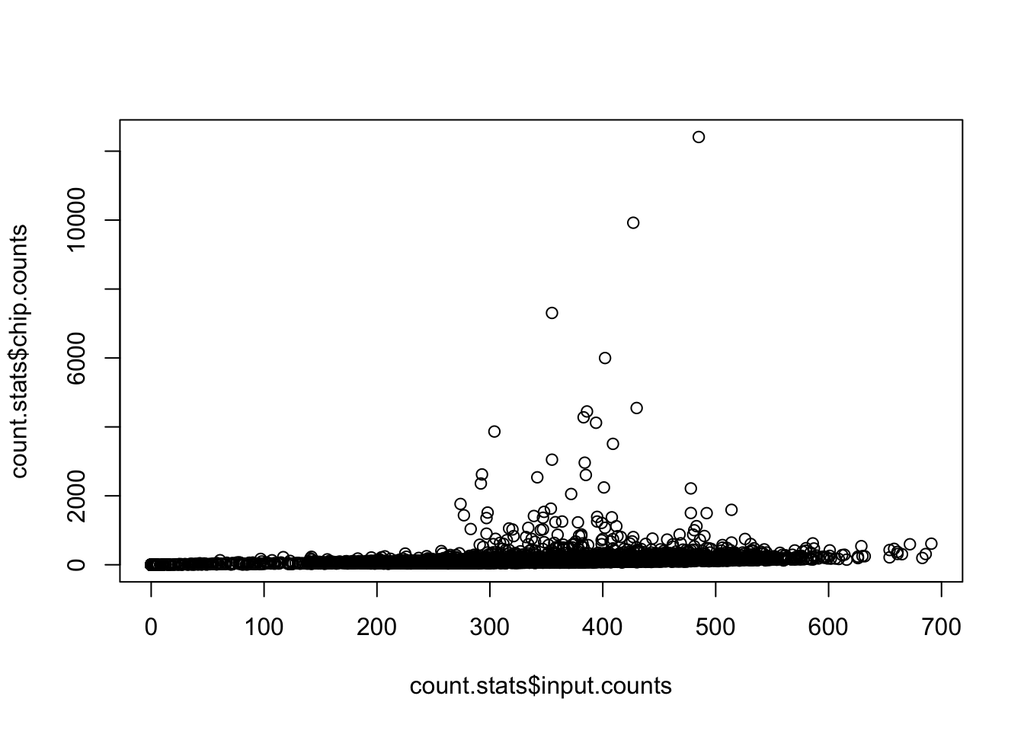

```r
par(mfrow=c(1,1))
plot(x= count.stats$input.counts, y= count.stats$chip.counts)
```

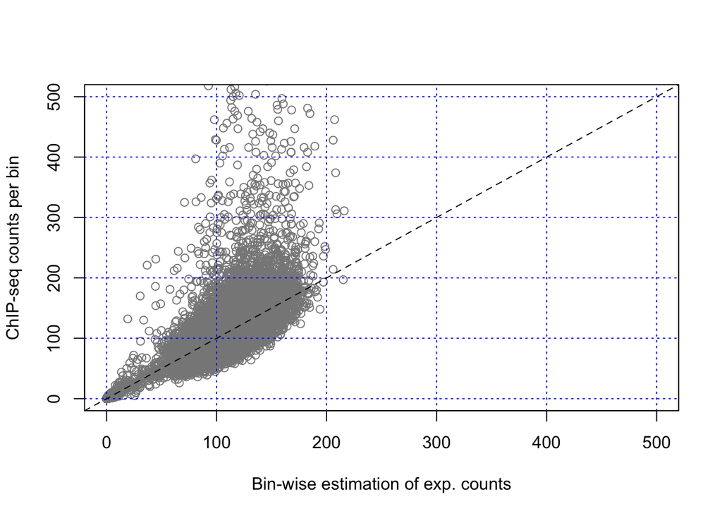

```r
plot(x= count.stats$input.counts.norm,
     xlab="Bin-wise estimation of exp. counts",
     ylab="ChIP-seq counts per bin",
     y= count.stats$chip.counts, col="#888888",
     xlim=c(0,500), ylim=c(0,500))
grid(col="blue")
abline(a=0, b=1, col="black", lty="dashed")
```

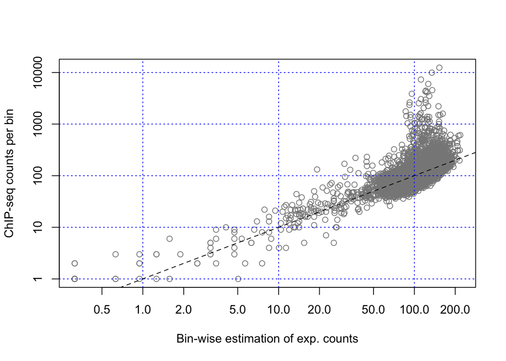

```r
## Same plot with log axes
plot(x= count.stats$input.counts.norm,
     xlab="Bin-wise estimation of exp. counts",
     ylab="ChIP-seq counts per bin",
     y= count.stats$chip.counts, col="#888888", log="xy")
grid(col="blue")
abline(a=0, b=1, col="black", lty="dashed")
```

## Count ratios

The most intuitive (and spontanous) way of comparing tow numbers is to comupte their ratio. However, the ratio can be problematic because it will emphasize small-number fluctuations.

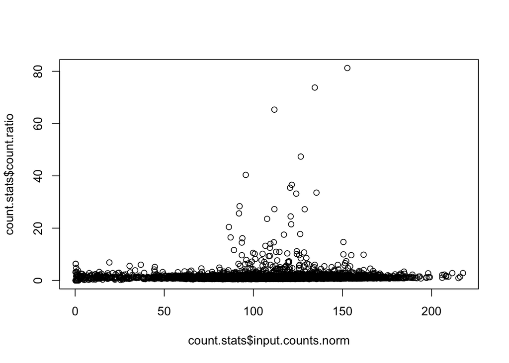

```r
count.stats$count.ratio <- count.stats$chip.counts / count.stats$input.counts.norm
plot(count.stats$input.counts.norm, count.stats$count.ratio)
```

## Log2-ratio

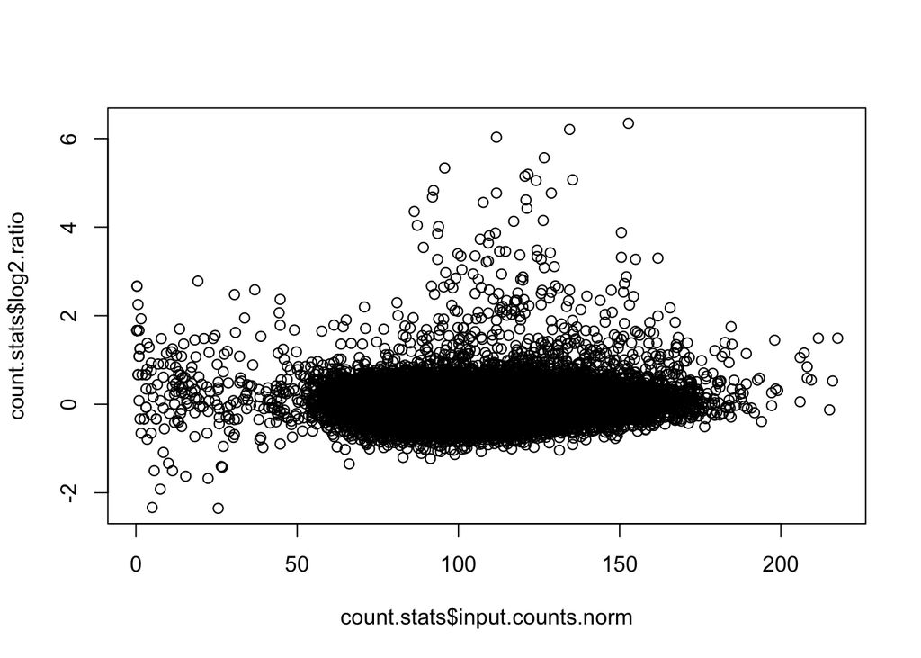

```r
count.stats$log2.ratio <- log2(count.stats$count.ratio)
plot(count.stats$input.counts.norm, count.stats$log2.ratio)
```

## Compute the p-value

In a first time, we will naively consider that the normalized input counts per bin can serve as estimate of the expected counts in the same bins.

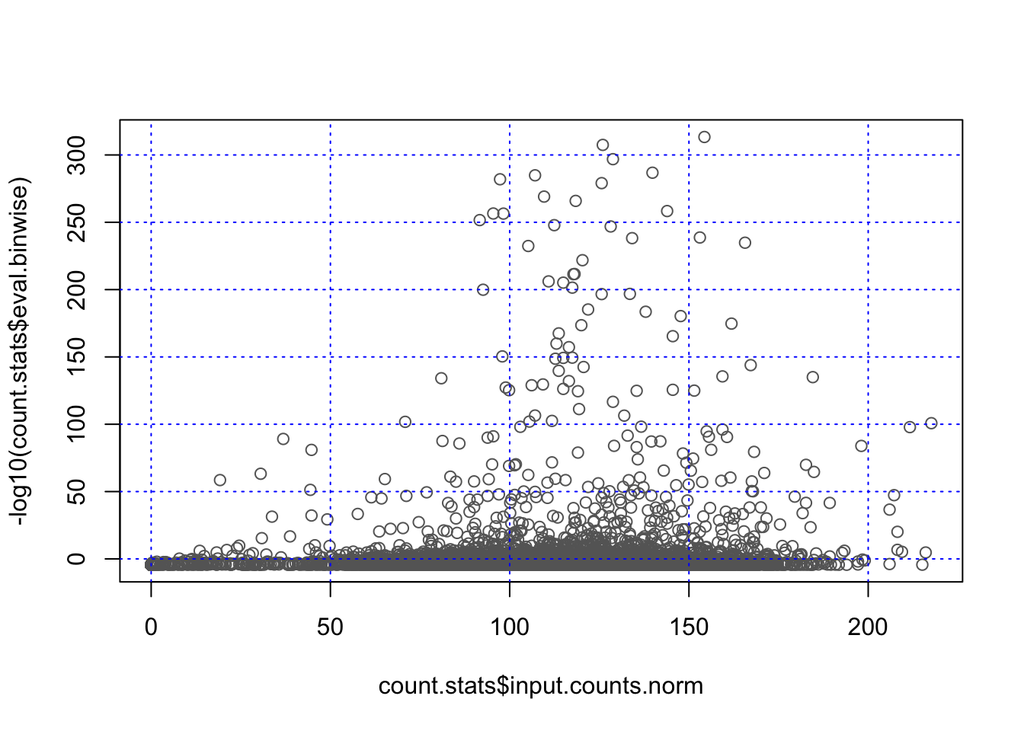

```r
count.stats$pval.binwise <- ppois(
  q = count.stats$chip.counts - 1,
  lambda = count.stats$input.counts.norm,
  lower.tail=FALSE)
count.stats$eval.binwise <- count.stats$pval.binwise * nbins

plot(
  count.stats$input.counts.norm,
  -log10(count.stats$eval.binwise),
  col="#666666"
     )
grid(col="blue")
```

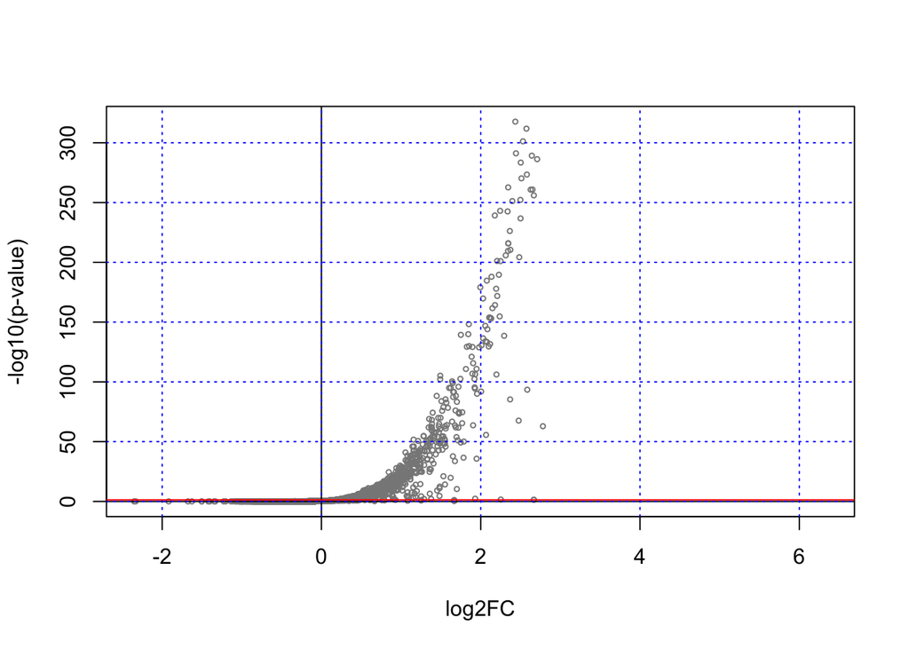

```r
alpha=0.05

## Volcano plot
plot(
  count.stats$log2.ratio,
  -log10(count.stats$pval.binwise),
  xlab="log2FC",
  ylab="-log10(p-value)",
  cex=0.5,
  col="#888888")
abline(h=0, col="black")
abline(v=0, col="black")
grid(col="blue")
abline(h=-log10(alpha), col="red")
```